# Medidas de tendencia central

Son una manera de resumir información, como un conjunto de datos. Hay ventajas y desventajas de todo esto, Ventaja: Extraer información valiosa de un conjunto de datos: Desventaja: ¿Qué pasa si hay datos en extremos, es decir números pequeños o grandes, comparados con los demás datos. El promedio no nos da información sobre estos datos.

- Media (promedio): Tiene que ver con una noción de centralidad de los datos. O promedio de todos los datos, puede ser susceptible a valores atípicos.
- Mediana (dato central): Es un primo que tiene la media, es básicamente el dato que está en la mitad. Los datos tienen que estar ordenados de manera ascendente y esto depende de si el número de datos es par o impar, es decir es un valor que está perfectamente balanceado y que está justamente en la mitad (tiene a los lados la mismta cantidad de datos).
- Moda (dato que más se repite): Es simplemente el dato o el valor de esa variable que más se repite.

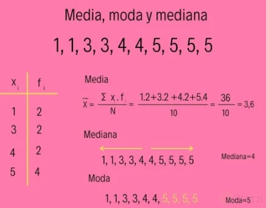

### Diagrama de frecuencia - tabla de frecuencias

La tabla de fecuencias y su representación grafica se contruye de la siguiente manera:

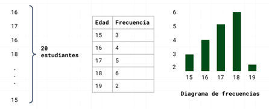

**Ejemplo:** Tenemos un salón de clases con $20$ estudiantes con edades diferentes, lo que yo quiero es contar con que frecuencia se repite el número de estudiantes de cierta edad, es decir qué tan común es cada una de estas edades. Lo que hago es elegir el parámetro que quiero medir su frecuencia y lo ordeno de menor a mayor, es decir el número más pequeño lo pongo primero, luego pongo el número de frecuencia que aparace tal valor en el conjunto de datos y así con los demás datos. Este es un dato discreto, es decir solo se cuenta por unidad o numeros enteros.

Es apropiado que al hacer un análisis hagamos una representación gráfica de los datos mediante el **Diagrama de frecuencias (gráfica de barras)** porque siempre es mas sencillo visualizar un imagen a un conjunto de datos .

¿Por qué es importante? Porque los estadísticos se pueden representar en términos de ese diagrama.

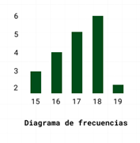

Digamos de esta gráfica es fácil ver la **moda**, porque es la barra mas alta.

La media es susceptible a valores atípicos. Ejemplo: yo tengo un conjunto de personas, y esas personas tienen edades muy cercanas y de pronto llego otra persona que tiene una edad muy alta. Calculo el promedio de todas las personas, lo que va a suceder es que la medida resultante de lo que el promedio representa se va a ver fuertemente afectada por esa persona que tiene una edad muy pequeña o muy grande.

En general la persona que posea una edad muy distante de los datos restantes que tienen una distribución más cercana entre ellas. Esa es una desventaja del **promedio**, cosa que no pasa con la mediana.

Entonces empezamos a pensar; ¿qué datos me conviene representar con la media, o con la mediana. En el caso de la moda no aplica para dots numéricos continuos.

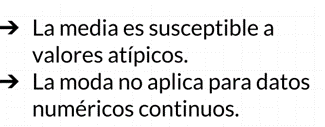

# Extra

++Desventajas++ • Es sensible a los valores extremos. Si alguno de los valores es extremadamente grande o extre-madamente pequeño, la media no es el promedio apropiado para representar la serie de datos. • No es recomendable emplearla en distribuciones muy asimétricas. • Si se emplean variables discretas o cuasi-cualitativas, la media aritmética puede no pertenecer al conjunto de valores de la variable.

Como dato curioso e interesante:  
No solo existen esas 3 medidas de tendencias central, hay otras más poco conocidas, pero las abordaremos ahora mismo.

- Media ponderada: es una medida de tendencia central, que es apropiada cuando en un conjunto de datos cada uno de ellos tiene una importancia relativa (o peso) respecto de los demás datos. Se obtiene multiplicando cada uno de los datos por su ponderación (peso) para luego sumarlos, obteniendo así una suma ponderada; después se divide esta entre la suma de los pesos, dando como resultado la media ponderada.
- Media armónica: La media armónica es igual al número de elementos de un grupo de cifras entre la suma de los inversos de cada una de estas cifras. En otras palabras, la media armónica es una medida estadística recíproca a la media aritmética, que es la suma de un conjunto de valores entre el número de observaciones.
- Media geométrica: es una cantidad arbitraria de números (por decir n números) es la raíz n-ésima del producto de todos los números; es recomendada para datos de progresión geométrica, para promediar razones, interés compuesto y números índice.

[figure not shown]